# 车载数据分析与驾驶员行为推测

归正涛 PB20000262

2022-05-07

# 任务一：加载数据并初看分布

```r
data0 = read.csv("data.csv",header = T)    #读入样本数据
summary(data0)
```

```
##      TIME                LONG            LAT            CONSUM
##  Length:1575        Min.   :122.1   Min.   :40.16   Min.   : 0.000
##  Class :character   1st Qu.:122.1   1st Qu.:40.17   1st Qu.: 2.400
##  Mode  :character   Median :122.1   Median :40.19   Median : 6.400
##                     Mean   :122.1   Mean   :40.19   Mean   : 7.564
##                     3rd Qu.:122.1   3rd Qu.:40.21   3rd Qu.:11.300
##                     Max.   :122.1   Max.   :40.21   Max.   :20.000
##     LONGACC            SPEED            WHEEL            CUMDIS
##  Min.   :-8.6600   Min.   : 0.000   Min.   : 657.5   Min.   :3127
##  1st Qu.:-0.6200   1st Qu.: 8.925   1st Qu.: 947.5   1st Qu.:3129
##  Median :-0.4200   Median :32.175   Median :1401.5   Median :3133
##  Mean   :-0.4224   Mean   :32.740   Mean   :1354.2   Mean   :3134
##  3rd Qu.:-0.1400   3rd Qu.:54.375   3rd Qu.:1669.4   3rd Qu.:3139
##  Max.   : 1.6400   Max.   :86.625   Max.   :2650.0   Max.   :3141
```

# 任务二：数据预处理

将时间转化为R语言中的时间格式，并处理缺失值

```r
Time = as.POSIXct(data0$TIME)
head(data0,6)
```

```
##               TIME     LONG      LAT CONSUM LONGACC  SPEED   WHEEL CUMDIS
## 1 2016/11/11 19:50 122.0951 40.20291    6.1   -0.22 37.875 1505.00   3127
## 2 2016/11/11 19:50 122.0951 40.20291    6.6   -0.32 38.400 1534.50   3127
## 3 2016/11/11 19:50 122.0951 40.20291    5.6   -0.32 38.625 1532.75   3127
## 4 2016/11/11 19:50 122.0951 40.20291    5.0   -0.98 37.425 1485.50   3127
## 5 2016/11/11 19:50 122.0951 40.20291    3.0   -0.88 36.075 1426.25   3127
## 6 2016/11/11 19:50 122.0951 40.20291    0.8   -0.78 34.575 1374.75   3127
```

```r
colnames(data0)
```

```
## [1] "TIME"    "LONG"    "LAT"     "CONSUM"  "LONGACC" "SPEED"   "WHEEL"
## [8] "CUMDIS"
```

```r
data0$time<-c(1:1575)
```

看上去好像没什么变化，不过改了就会比较放心，因为许多参数使用会涉及格式规范性

# 任务三：用图像初步分析数据

## 1.分析驾驶员开车情况(车速与加速度的概况)

```r
summary(data0$SPEED)
```

```
##    Min. 1st Qu.  Median    Mean 3rd Qu.    Max.
##   0.000   8.925  32.175  32.740  54.375  86.625
```

```r
summary(data0$LONGACC)
```

```
##    Min. 1st Qu.  Median    Mean 3rd Qu.    Max.
## -8.6600 -0.6200 -0.4200 -0.4224 -0.1400  1.6400
```

#### 从数据中可以发现，加速度的最小值极大，我们将其归为异常点，需要进一步处理，速度呈现两极分化状态。

## 1.绘制小车速度分布饼图

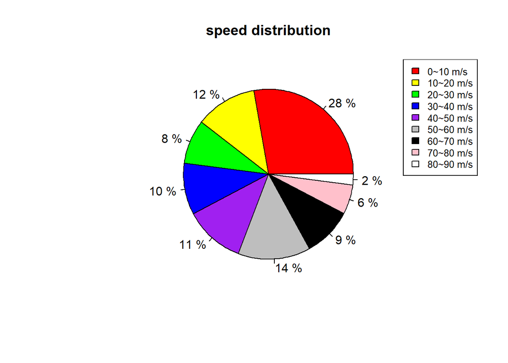

```r
dataspeed<-c(nrow(data0[data0$SPEED < 10,]) , nrow(data0[10<=data0$SPEED& data0$SPEED< 20,]), nrow(data0[20<=data0$SPEED&data0$SPEED < 30,]),nrow(data0[30<=data0$SPEED&data0$SPEED < 40,]),nrow(data0[40<=data0$SPEED&data0$SPEED < 50,]),nrow(data0[50<=data0$SPEED&data0$SPEED < 60,]),nrow(data0[60<=data0$SPEED&data0$SPEED < 70,]),nrow(data0[70<=data0$SPEED&data0$SPEED < 80,]),nrow(data0[80<=data0$SPEED&data0$SPEED < 90,]))
names = c("0~10 m/s", "10~20 m/s", "20~30 m/s", "30~40 m/s","40~50 m/s","50~60 m/s","60~70 m/s","70~80 m/s","80~90 m/s")
cols = c("red","yellow","green","blue","purple","gray","black","pink","white")
# 计算百分比
piepercent = paste(round(100*dataspeed/sum(dataspeed)), "%")
# 绘图
pie(dataspeed, labels=piepercent, main = "speed distribution", col=cols)
# 添加颜色样本标注
legend("topright", names, cex=0.8, fill=cols)
```

## 2.折线图(绘制各变量随着时间变化的分布)

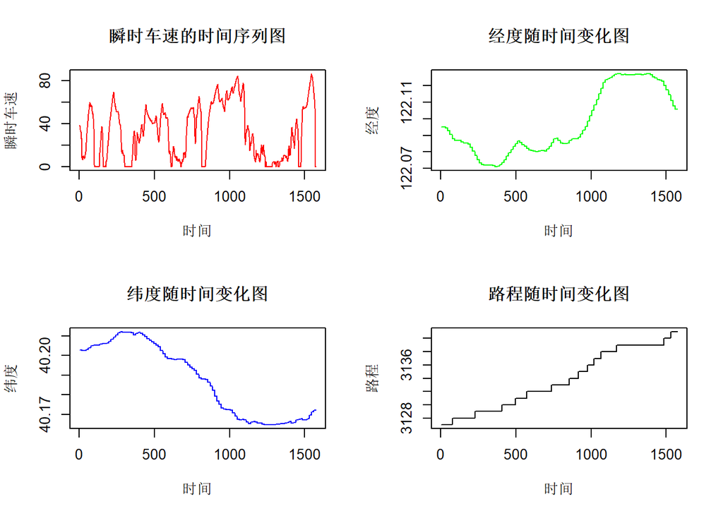

上述图片我们占时无法发现有价值的信息，故需要对数据进行进一步分析

## 3.初步查看变量之间的关系

### 加速度与速度之间的关系

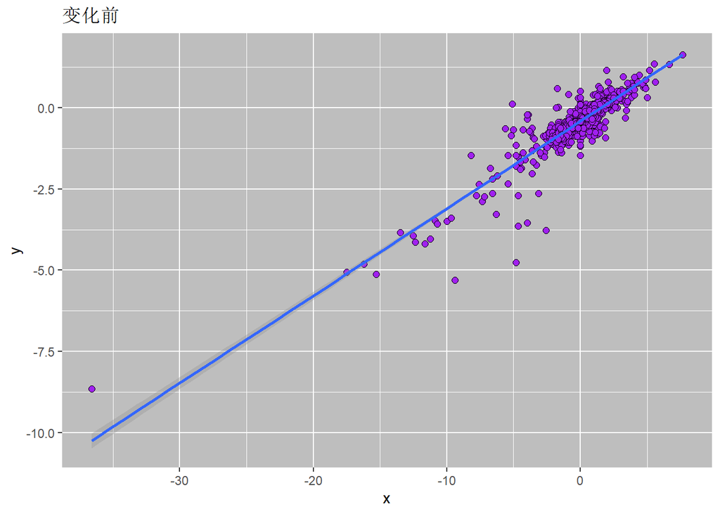

```r
library(ggplot2)
delta_speed<-0
for (i in (1:1575)) {
  delta_speed[i] <- data0$SPEED[i+1]-data0$SPEED[i]
}
x<-delta_speed
y<-data0$LONGACC[2:1576]
p1<-ggplot(data0, aes(x,y))+geom_point(size=2,shape=21,fill="purple")+ theme(panel.background = element_rect(fill = "gray"))+labs(title =  bquote("变化前"))+ geom_smooth(method="lm")
p1
```

```r
cor(diff(data0$SPEED),data0$LONGACC[2:1575]*3.6, use = "everything",method = c("pearson", "kendall", "spearman"))
```

```
## [1] 0.9060492
```

1.从图中，我们可以初步看到，速度变化率与加速度满足一定的正相关性，由常识，这是理所当然的。但分布并不是完全满足线性关系的，数据具有随机误差，故我们需要进行修正。

2.图中有个别看似异常的点，我们可以定义其为”离群点”，如最左下角的点，在数据集中偏离大部分数据，使我怀疑这些数据的偏离并非由随机因素产生，而是产生于完全不同的机制。这个在之后的误差分析中会有所涉及。

### 各变量与耗油量之间的关系

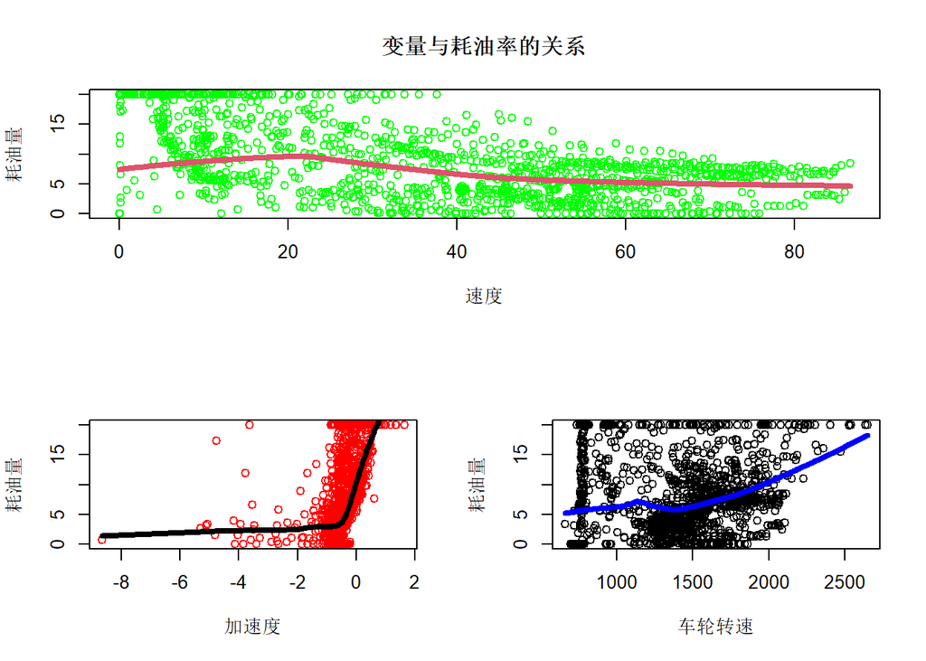

```r
layout(matrix(c(1,1,2,3), 2,2, byrow = TRUE))
plot( data0$SPEED , data0$CONSUM ,xlab = "速度",ylab = "耗油量", main = "变量与耗油率的关系",col = "green")
lines(lowess(data0$SPEED , data0$CONSUM),col=2,lwd = 4)
plot( data0$LONGACC , data0$CONSUM ,xlab = "加速度",ylab = "耗油量", main = "",col = "red")
lines(lowess(data0$LONGACC , data0$CONSUM),col=1,lwd = 4)
plot( data0$WHEEL , data0$CONSUM ,xlab = "车轮转速",ylab = "耗油量", main = "")
lines(lowess(data0$WHEEL , data0$CONSUM),col="blue",lwd = 4)
```

```r
cor(data0$SPEED , data0$CONSUM, use = "everything",method = c("pearson", "kendall", "spearman"))
```

```
## [1] -0.274646
```

```r
cor(data0$LONGACC , data0$CONSUM, use = "everything",method = c("pearson", "kendall", "spearman"))
```

```
## [1] 0.4144505
```

```r
cor(data0$WHEEL , data0$CONSUM, use = "everything",method = c("pearson", "kendall", "spearman"))
```

```
## [1] 0.1464317
```

#### 三者相关系数如上图所示

初步结论：耗油速度与加速度有一定的正相关性，与其他变量基本无关。车辆的耗油率有上限：20。，且都具有个别离群点。

### 各变量与车轮转速的关系

初步推测车轮转速与速度跟加速度有关

```r
library(quantreg)  # 载入quantreg包
```

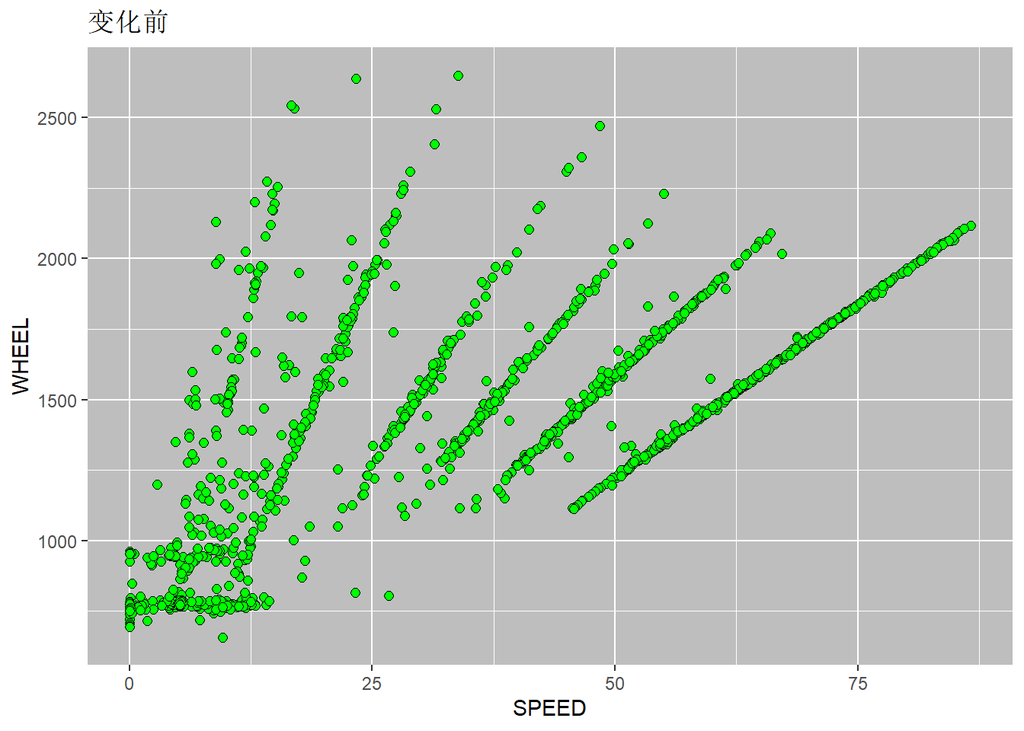

```r
p1<-ggplot(data0, aes(SPEED, WHEEL))+geom_point(size=2,shape=21,fill="green")+ theme(panel.background = element_rect(fill = "gray"))+labs(title =  bquote("变化前"))
p1
```

```r
cor(data0$SPEED , data0$WHEEL, use = "everything",method = c("pearson", "kendall", "spearman"))
```

```
## [1] 0.7174935
```

分析结论：

1.从图中可以看出，车轮转速与车速的相关性非常大，相关系数为0.7174935，基本跟加速度无关。究其原因，我百度了一下资料，汽车有一个档位设置，不同档位的作用不同。汽车行驶时，通过换挡可以使发动机工作在其最佳的动力性能状态下，所有的行驶状况都有相应的换档点，最终的目的是降低油耗。

2.这也是为什么图中有这么多条直线的原因，，不同的直线代表的不同的档位，当驾驶员换挡时，车轮转速会马上跳到另一个速度，然后随着速度的变化逐渐上升。

# 任务四:修正数据误差

之前提到，此数据具有一定的测量误差，所以我们需要对数据进行进一步处理，否则会为我们之后的数据分析提供障碍。

## 修正加速度误差

我们发现数据集中当速度为0时，耗油量为0，说明车主此时停车了，但此时的加速度却不为0，说明数据集中的加速度一定有误差，我们需要对其进行修正，以减少对后续分析带来的不便

```r
head(data0[data0$SPEED == 0, ]) #选择行子集
```

```
##                 TIME     LONG     LAT CONSUM LONGACC SPEED  WHEEL CUMDIS time
## 102 2016/11/11 19:51 122.0869 40.2053      0   -0.42     0 770.75   3128  102
## 103 2016/11/11 19:51 122.0869 40.2053      0   -0.42     0 774.75   3128  103
## 104 2016/11/11 19:51 122.0869 40.2053      0   -0.38     0 723.50   3128  104
## 105 2016/11/11 19:51 122.0869 40.2053      0   -0.42     0 705.25   3128  105
## 106 2016/11/11 19:51 122.0869 40.2053      0   -0.38     0 707.00   3128  106
## 107 2016/11/11 19:51 122.0869 40.2053      0   -0.42     0 707.00   3128  107
```

```r
mean(data0[data0$SPEED == 0, ]$LONGACC) #对此行子集的加速度取平均值
```

```
## [1] -0.4438674
```

```r
data1 <- data0
data1$LONGACC <- data0$LONGACC + mean(data0[data0$SPEED == 0, ]$LONGACC)*(-1)
```

## 绘制加速度修改对比图

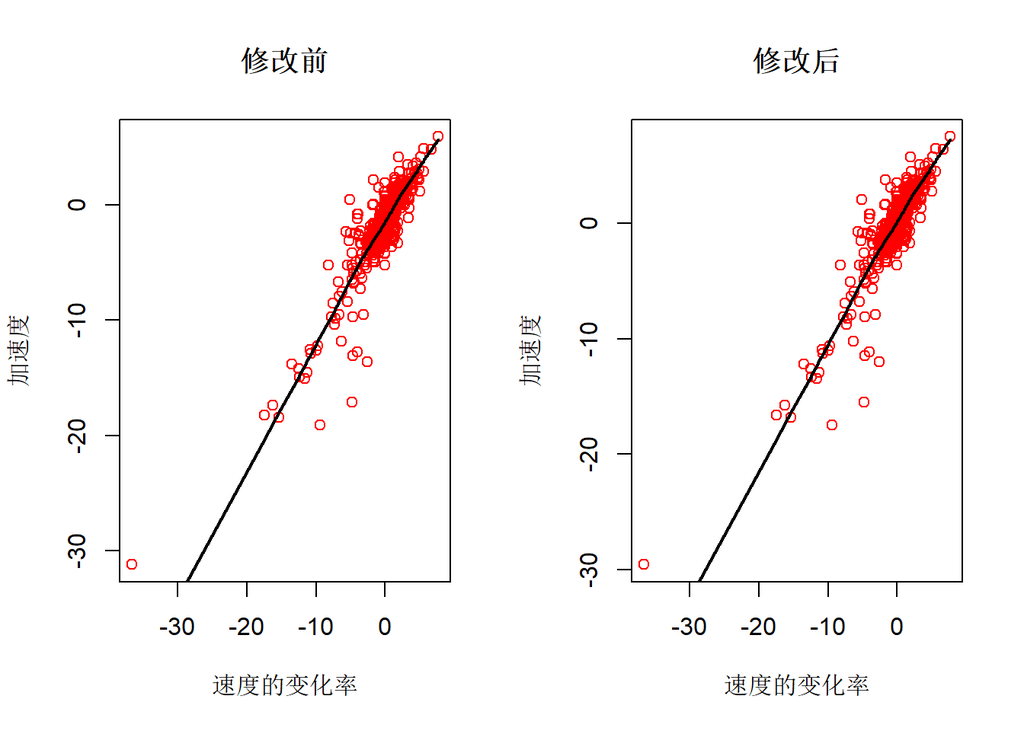

```r
par(mfrow=c(1,2))
delta_speed<-0
for (i in (1:1574)) {
  delta_speed[i] <- data0$SPEED[i+1]-data0$SPEED[i]
}
plot( delta_speed , data0$LONGACC[2:1575]*3.6,xlab = "速度的变化率",ylab = "加速度", main = "修改前",col = "red")
lines(lowess(diff(data0$SPEED),data0$LONGACC[2:1575]*3.6),col=1,lwd = 2)
plot( delta_speed , data1$LONGACC[2:1575]*3.6,xlab = "速度的变化率",ylab = "加速度", main = "修改后",col = "red")
lines(lowess(diff(data1$SPEED),data1$LONGACC[2:1575]*3.6),col=1,lwd = 2)
```

经简单修正，测试修改前，与修改后速度跟加速度的误差(理论上误差应该为0)剩余的我们可以将其归类为不可避免的随机误差，可以忽略。

## 比较修改前后均方误差的变化

```r
mse <- 0
for (i in (1:1574)) {
  mse = mse + (delta_speed[i] - data0$LONGACC[i+1]*3.6)^2
}
mse<-mse/1574
print(mse)
```

```
## [1] 3.171052
```

```r
mse1 <- 0
for (i in (1:1574)) {
  mse1 = mse1 + (delta_speed[i] - data1$LONGACC[i+1]*3.6)^2
}
mse1<-mse1/1574
print(mse1)
```

```
## [1] 0.9396621
```

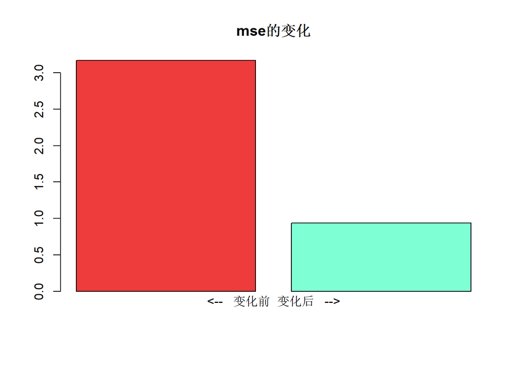

```r
res<-c(mse,mse1)
barplot(res, main="mse的变化", col=c("brown2", "aquamarine1"))
mtext("<--   变化前  变化后   -->", side = 1)
```

#### 处理前与处理后的均方误差从3.171052减到了0.9396621

可以发现，修改后两者的均方误差减少了很多，这为我们后续分析提供了便利

## 去除离群点带来的负面影响

离群点：在数据集中偏离大部分数据的数据，使人怀疑这些数据的偏离并非由随机因素产生，而是产生于完全不同的机制。与数据集中其余部分不服从相同统计模型足够地不同于数据集中其余部分的数据，足够地不同于数据集中其余部分的数据。

离群点的来源：

1.客体的异常行为导致，如欺诈、入侵、不寻常的实验结果。

2.数据测量和收集误差、度量或执行错误所导致的。例如，一个人的年龄为-999可能是由于对年龄的默认设置所产生的。

3.数据变量内在特性引起。例如,顾客新的购买模式、基因突变等:一个公司的首席执行官的工资远远高于公司其他雇员的工资，也可成为一个离群点。

1.箱线图法初探

```r
par(mfrow=c(1,3))
library(ggplot2)
x<-data1$CONSUM
y<-data1$WHEEL
z<-data1$SPEED
boxplot(x,col = "purple",xlab = "耗油率的离群点");boxplot.stats(x,coef=1.5)$out
```

```
## numeric(0)
```

```r
boxplot(y,col = "blue",xlab = "车轮转速的离群点");boxplot.stats(y,coef=1.5)$out
```

```
## numeric(0)
```

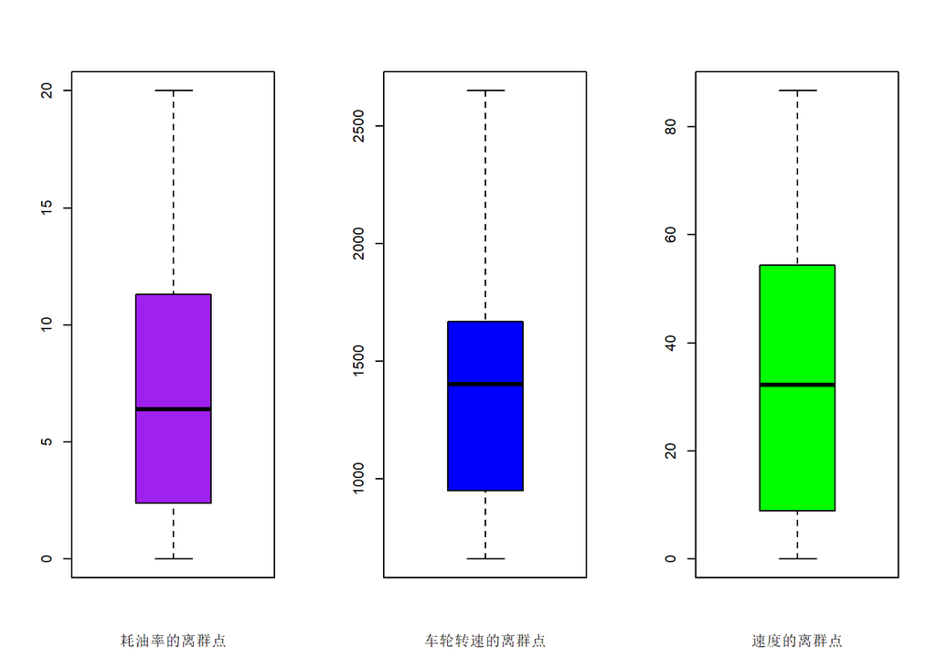

```
## numeric(0)
```

```r
boxplot(z,col = "green",xlab = "速度的离群点");boxplot.stats(z,coef=1.5)$out
```

2.标记离群点的值

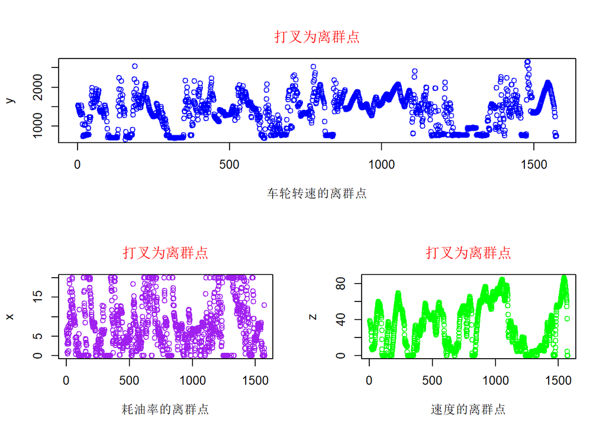

```r
layout(matrix(c(1,1,2,3), 2,2, byrow = TRUE))
xlist<-which(x %in% boxplot.stats(x,coef =1.5)$out)
ylist<-which(y %in% boxplot.stats(y,coef =1.5)$out)
zlist<-which(z %in% boxplot.stats(z,coef =1.5)$out)
plot(y,col = "blue",xlab = "车轮转速的离群点")
mtext("打叉为离群点",col = "red", side = 3, line = 1)
plot(x,col = "purple",xlab = "耗油率的离群点")
mtext("打叉为离群点",col = "red", side = 3, line = 1)
plot(z,col = "green",xlab = "速度的离群点")
mtext("打叉为离群点",col = "red", side = 3, line = 1)
points(data1[ylist,],col="red",pch="x",cex=1)
points(data1[xlist,],col="red",pch="x",cex=1)
points(data1[zlist,],col="red",pch="x",cex=1)
```

从图中不难看出，三者变量均没有离群点，因此我们不需要对数据进行进一步修改。

误差处理初步结束！通过各项误差处理，我们得到了修改后的数据集data1.

# 任务五:绘制车辆行驶轨迹图

根据车辆的经度与纬度关于时间的变化(因为短距离行驶，我们忽略地球是球体而给结果带来的影响，将行驶地图近似成一个平面图)，我们可以绘制小车行程的平面图。

小车平面轨迹图

[figure not shown]

```r
library(ggplot2)
plot(data1$LONG,data1$LAT, type = "l", xlab = "经度",col = "blue", ylab =  "纬度",main="小车行驶路线图")
text(122.12, 40.1675, "<",cex = 2,col = "red")
text(122.10, 40.1728, "<",cex = 2,col = "red")
text(122.08, 40.2082, "<",cex = 2,col = "red")
text(122.12, 40.21, "< : 行驶方向",cex = 1.5,col = "black")
```

#### 结合三维地图，图中大致描绘了小车的行驶路线，地图按上北下南左西右东标准处理，并忽略地球是球体的影响

绘制经度纬度速度加速度概率密度图

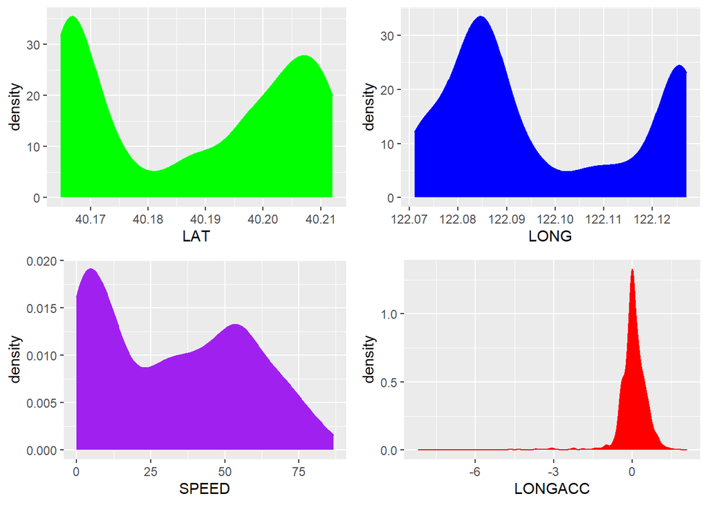

```r
library(ggpubr)
p<-ggplot(data1, aes(x = LAT)) + geom_density(color = "green", fill = "green")
q<-ggplot(data1, aes(x = LONG))+geom_density(color = "blue", fill = "blue")
n<-ggplot(data1, aes(x = SPEED))+geom_density(color = "purple", fill = "purple")
m<-ggplot(data1, aes(x = LONGACC))+geom_density(color = "red", fill = "red")
ggarrange(p,q,n,m ,ncol=2, nrow=2, legend="bottom")
```

绘制小车行驶路线三维轨迹图

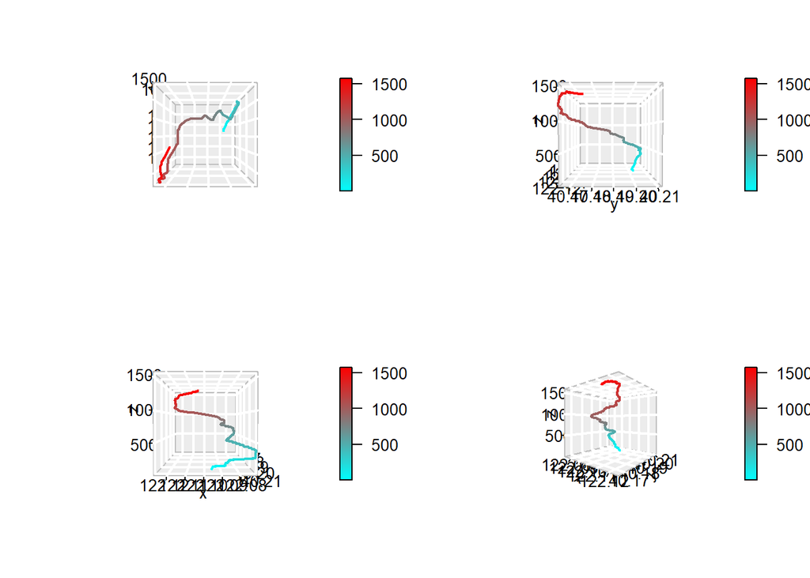

```r
library(plot3D)
x<-c(1:1574)
y<-c(1:1574)
z<-c(1:1574)
for (i in (1:1574)) {
  x[i]<-data1$LONG[i]
  y[i]<-data1$LAT[i]
  z[i]<-i
}
par(mfrow=c(2,2))
scatter3D(x, y, z,
          phi = 90,theta = 90, type = "l",
          col = ramp.col(col=c("cyan","red"),
          n=length(z)),ticktype = "detailed",
          lwd = 2, bty = "g")
scatter3D(x, y, z,
          phi = 1,theta = 90, type = "l",
          col = ramp.col(col=c("cyan","red"),
          n=length(z)),ticktype = "detailed",
          lwd = 2, bty = "g")
scatter3D(x, y, z,
          phi = 1,theta = 180, type = "l",
          col = ramp.col(col=c("cyan","red"),
          n=length(z)),ticktype = "detailed",
          lwd = 2, bty = "g")
scatter3D(x, y, z,
          phi = 1, type = "l",
          col = ramp.col(col=c("cyan","red"),
          n=length(z)),ticktype = "detailed",
          lwd = 2, bty = "g")
```

从上述程序中，我们描绘了车辆在行驶时的运动路径图，记录了各点的经度纬度位置，以及经度纬度的概念密度图，从而开始了驾驶员行为分析的第一步。

# 任务六:车辆档位数据提取的聚类分析

通过老师的指导，本实验采用了统计学的一种回归分析方法————分位数回归法。一般地，传统的回归分析研究自变量与因变量的条件期望之间的关系，相应得到的回归模型可由自变量的估计因变量的条件期望；分位数回归研究自变量与因变量的条件分位数之间的关系，相应得到的回归模型可由自变量估计因变量的条件分位数。相较于传统回归分析仅能得到因变量的中央趋势，分量回归可以进一步推论因变量的条件概率分布。分位数回归属于非参数统计方法之一。

由于本实验散点的分布集中在一条直线上，故本实验无法采用传统的Kmeans聚类算法，原因是Kmeans的原理是对最近的点归为一类，而本实验的数据不是团状聚集在一起而是汇聚在一条直线左右，故经过思考，本人打算直接计算点到直线的距离，通过将距离设定为合适的阈值，从而挑选出合适的数据集。

## 分位数回归拟合数据

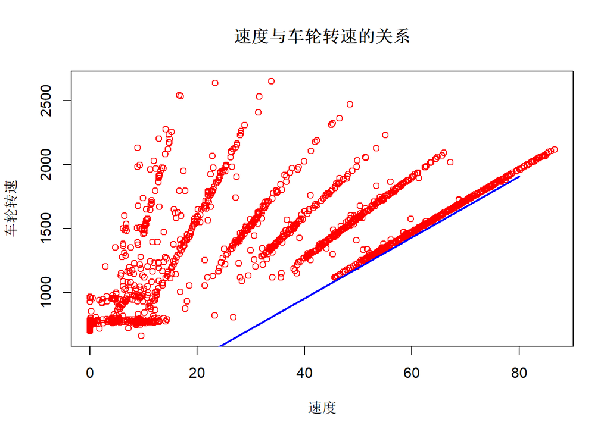

```r
fit2 = rq(data1$SPEED~data1$WHEEL, tau = 0.9, data = data1)#以0.92为分位数的对data1的speed和wheel的拟合
plot(data1$SPEED, data1$WHEEL,xlab = "速度",ylab = "车轮转速", main = "速度与车轮转速的关系",col= "red")   #画出data1的图
lines(c(0,80),c(0,23.81667*(80)),lwd=2, col = "blue") #将拟合直线放在图上
```

```r
datafit<-fitted(fit2)    #分位数回归拟合的数据
lm<-lm(formula=data1$WHEEL~datafit)  #提取直线
print(coef(lm))   #拟合直线参数
```

[output not shown]

## 聚类分析提取数据

```r
for (i in (1:1575)) {
  data1$d[i] = abs(23.81667*data1$SPEED[i]-data1$WHEEL[i])/sqrt(23.81667*23.81667+1)
}   #在data1中扩充一个d列，用来存放到拟合直线的距离
head(data1[data1$d<5,])  #提取距离一定值的数据
```

```
##                TIME     LONG      LAT CONSUM    LONGACC  SPEED   WHEEL CUMDIS
## 72 2016/11/11 19:51 122.0903 40.20401    2.9 -0.1361326 58.725 1437.00   3127
## 73 2016/11/11 19:51 122.0903 40.20401    1.3 -0.4161326 57.450 1407.00   3127
## 74 2016/11/11 19:51 122.0903 40.20401    1.3 -0.6761326 56.175 1387.00   3127
## 75 2016/11/11 19:51 122.0903 40.20401    0.4  0.2238674 55.950 1363.25   3127
## 76 2016/11/11 19:51 122.0879 40.20495    3.5  0.1638674 56.025 1372.75   3128
## 77 2016/11/11 19:51 122.0879 40.20495    4.7 -0.0361326 56.100 1410.25   3128
##    time        d
## 72   72 1.609473
## 73   73 1.624837
## 74   74 2.059706
## 75   75 1.288185
## 76   76 1.611780
## 77   77 3.109988
```

```r
data2<-data1[data1$d>5,]  #将这部分数据赋值给新的数据data2
data1$class<-0
data1$class[data1$d<5] <- "第一档"
data1$class[data1$WHEEL<1020]<-"发动档"
```

data1[data1$d<5,]就是我们提取的在直线附近的点，那么其余的点就是距离大于5的点，将这些点赋值给data2，方便下一步的计算，我们先画图观察。

## 提取发动档的点

经过查资料发现，汽车驾驶员在驾驶汽车点火时挡位在p挡和n挡都可以，自动挡汽车的起步方法：1、将钥匙插到钥匙孔内拧一格，让汽车电脑系统自检；2、踩下刹车后将钥匙转到点火挡，启动发动机；3、打下转向灯后踩下脚踩，挂D挡松开手刹即可。自动挡是不用驾驶者去手动换挡，车辆会根据行驶的速度和交通情况自动选择合适的挡位行驶，其挡位分为：1、p挡是泊车挡，启动挡；2、r挡是倒车挡；3、n挡是空挡；4、d挡是前进挡，也称驱动挡；5、l挡是低速挡；6、s挡是运动模式。

为简化分析，我们将汽车从速度0开始启动时的汽车档位记为发动档，亦称停档，其余档位称为一到六档，以此命名。

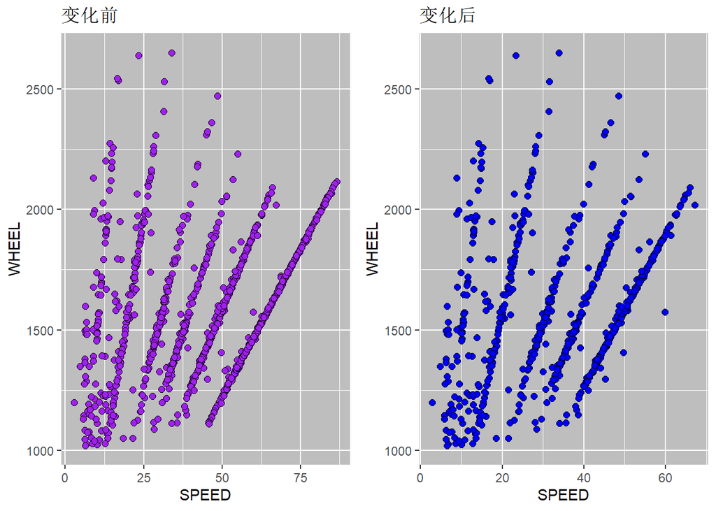

```r
library(ggplot2)
library(gridExtra)
par(mfrow=c(1,2))
p1<-ggplot(data1[data1$class != "发动档",], aes(SPEED, WHEEL))+geom_point(size=2,shape=21,fill="purple")+ theme(panel.background = element_rect(fill = "gray"))+labs(title =  bquote("变化前"))
p2<-ggplot(data1[data1$class == 0,], aes(SPEED, WHEEL))+geom_point(size=2,shape=21,fill="blue")+
theme(panel.background = element_rect(fill = "gray"))+labs(title =  bquote("变化后"))
grid.arrange(p1,p2,nrow=1)
```

数据提取非常成功！我们参考上述方法，继续对data2进行下一次的分位数回归与聚类分析。

## 第二次提取

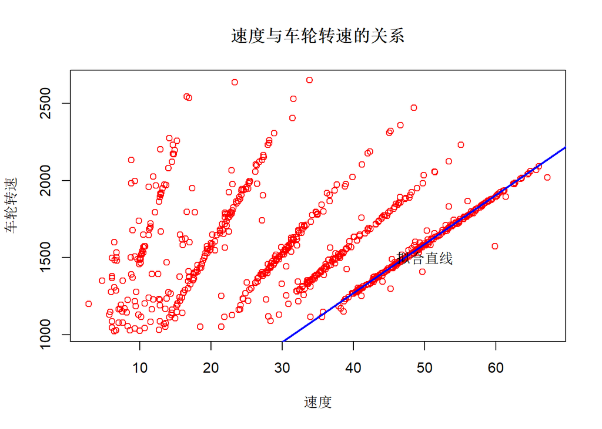

```r
fit3 = rq(data1[data1$class == 0,]$SPEED~data1[data1$class == 0,]$WHEEL, tau = 0.9, data=data1)#以0.92为分位数的对data1的speed和wheel的拟合
plot(data1[data1$class == 0,]$SPEED, data1[data1$class == 0,]$WHEEL,xlab = "速度",ylab = "车轮转速", main = "速度与车轮转速的关系",col= "red")   #画出data1的图
lines(c(0,80),c(0,31.798246*(80)),lwd=2, col = "blue") #将拟合直线放在图上
text(50, 1500, "拟合直线")
```

```r
datafit<-fitted(fit3)    #分位数回归拟合的数据
lm<-lm(formula=data1[data1$class == 0,]$WHEEL~datafit)  #提取直线
print(coef(lm))   #拟合直线参数
```

```
## (Intercept)     datafit
##   -9.740132   31.798246
```

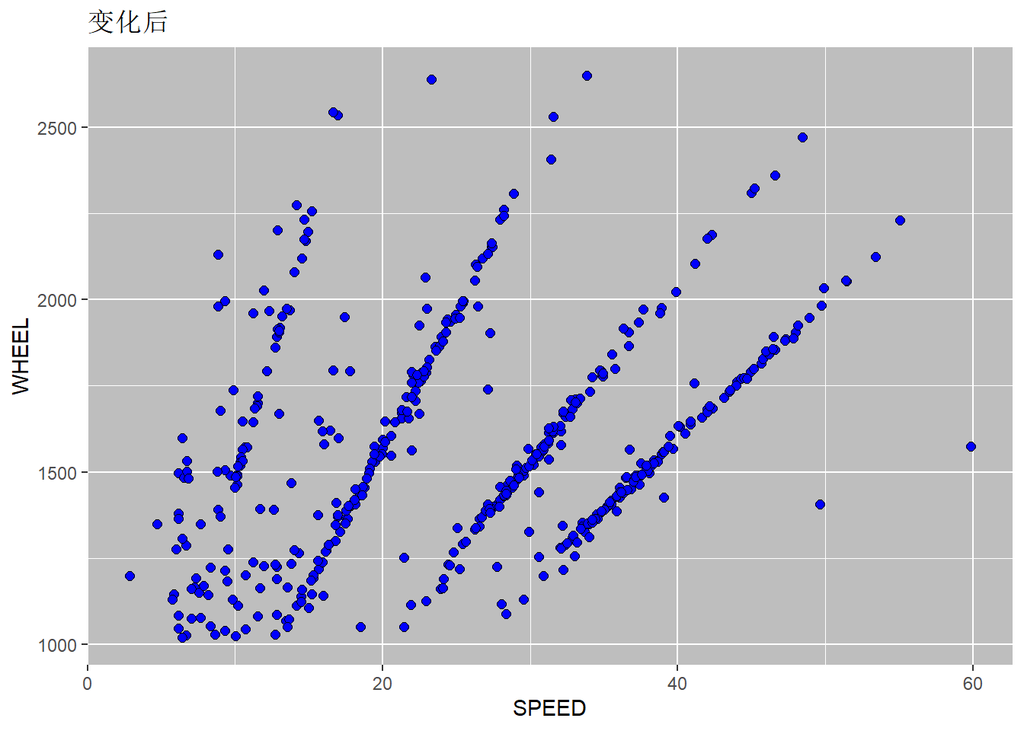

```r
for (i in (1:nrow(data1))) {
  data1$d1[i] = abs(31.798246*data1$SPEED[i]-data1$WHEEL[i])/sqrt(31.798246*31.798246+1)
}   #在data1中扩充一个d列，用来存放到拟合直线的距离
data1$class[data1$d1<5] <- "第二档"
p2<-ggplot(data1[data1$class == 0,], aes(SPEED, WHEEL))+geom_point(size=2,shape=21,fill="blue")+
theme(panel.background = element_rect(fill = "gray"))+labs(title =  bquote("变化后"))
p2
```

## 第三次提取

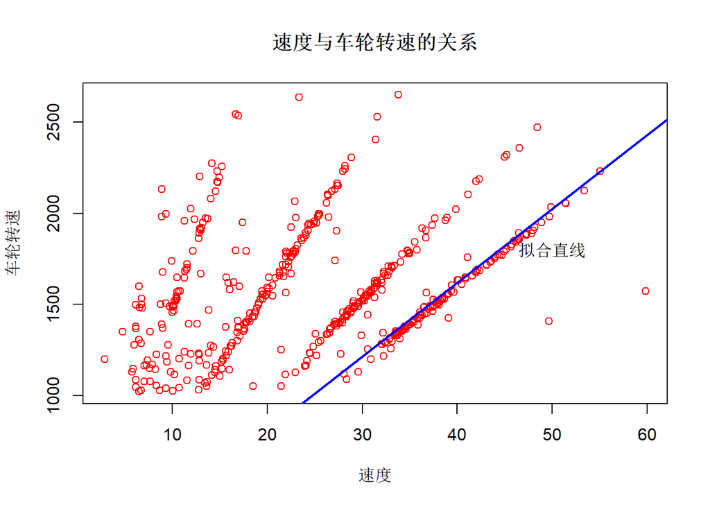

```r
fit4 = rq(data1[data1$class == 0,]$SPEED~data1[data1$class == 0,]$WHEEL, tau = 0.9, data=data1)#以0.92为分位数的对data1的speed和wheel的拟合
plot(data1[data1$class == 0,]$SPEED, data1[data1$class == 0,]$WHEEL,xlab = "速度",ylab = "车轮转速", main = "速度与车轮转速的关系",col= "red")   #画出data1的图
lines(c(0,80),c(0,40.54726 *(80)),lwd=2, col = "blue") #将拟合直线放在图上
text(50, 1800, "拟合直线")
```

```r
datafit<-fitted(fit4)    #分位数回归拟合的数据
lm<-lm(formula=data1[data1$class == 0,]$WHEEL~datafit)  #提取直线
print(coef(lm))   #拟合直线参数
```

```
## (Intercept)     datafit
##   -30.08955    40.54726
```

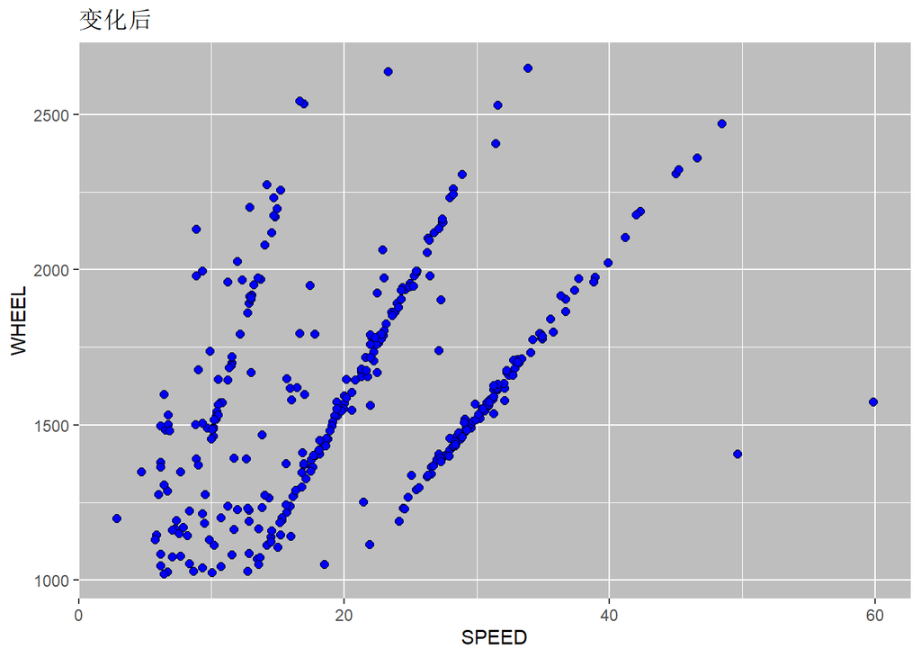

```r
for (i in (1:nrow(data1))) {
  data1$d2[i] = abs(40.54726 *data1$SPEED[i]-data1$WHEEL[i])/sqrt(40.54726 *40.54726 +1)
}   #在data1中扩充一个d列，用来存放到拟合直线的距离
data1$class[data1$d2<5] <- "第三档"
p2<-ggplot(data1[data1$class == 0,], aes(SPEED, WHEEL))+geom_point(size=2,shape=21,fill="blue")+
theme(panel.background = element_rect(fill = "gray"))+labs(title =  bquote("变化后"))
p2
```

## 第四次提取

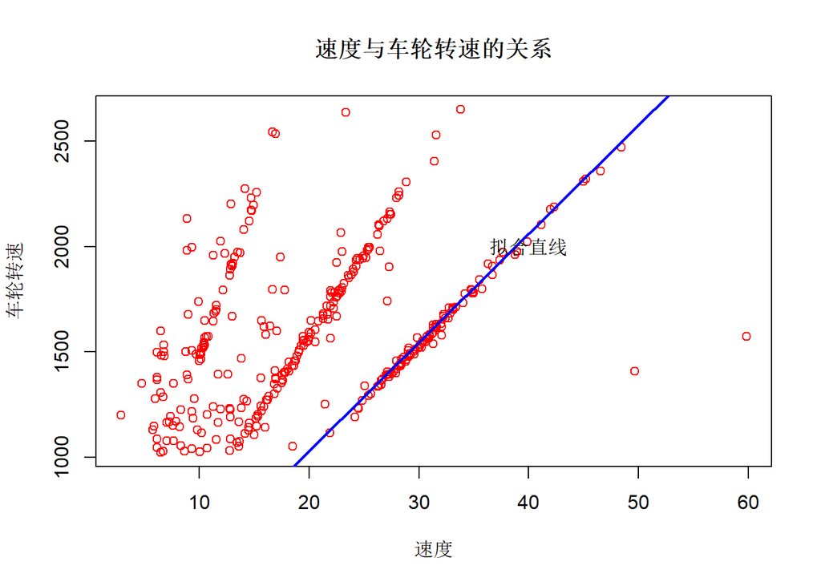

```r
fit5 = rq(data1[data1$class == 0,]$SPEED~data1[data1$class == 0,]$WHEEL, tau = 0.9, data=data1)#以0.92为分位数的对data1的speed和wheel的拟合
plot(data1[data1$class == 0,]$SPEED, data1[data1$class == 0,]$WHEEL,xlab = "速度",ylab = "车轮转速", main = "速度与车轮转速的关系",col= "red")   #画出data1的图
lines(c(0,80),c(0, 51.56863 *(80)),lwd=2, col = "blue") #将拟合直线放在图上
text(40, 2000, "拟合直线")
```

```r
datafit<-fitted(fit5)    #分位数回归拟合的数据
lm<-lm(formula=data1[data1$class == 0,]$WHEEL~datafit)  #提取直线
print(coef(lm))   #拟合直线参数
```

```
## (Intercept)     datafit
##   -23.66176    51.56863
```

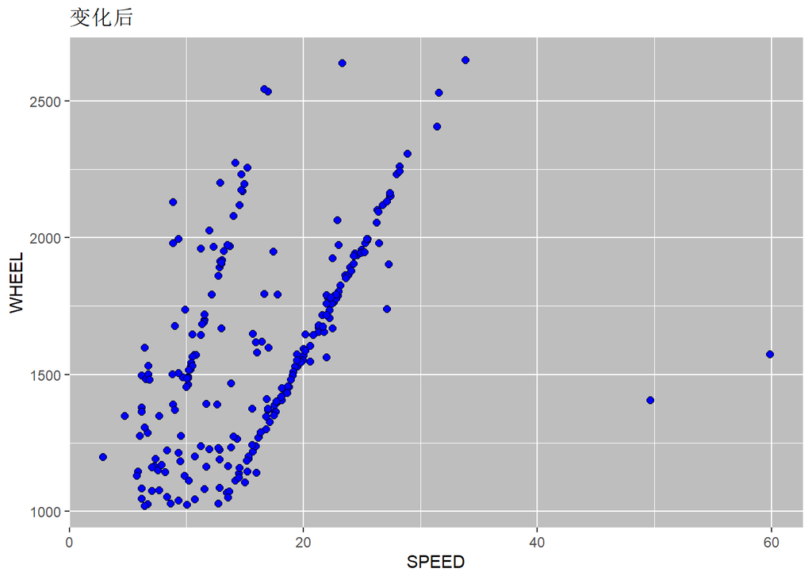

```r
for (i in (1:nrow(data1))) {
  data1$d3[i] = abs( 51.56863 *data1$SPEED[i]-data1$WHEEL[i])/sqrt( 51.56863 * 51.56863 +1)
}   #在data1中扩充一个d列，用来存放到拟合直线的距离
data1$class[data1$d3<5] <- "第四档"
p2<-ggplot(data1[data1$class == 0,], aes(SPEED, WHEEL))+geom_point(size=2,shape=21,fill="blue")+
theme(panel.background = element_rect(fill = "gray"))+labs(title =  bquote("变化后"))
p2
```

## 第五次提取

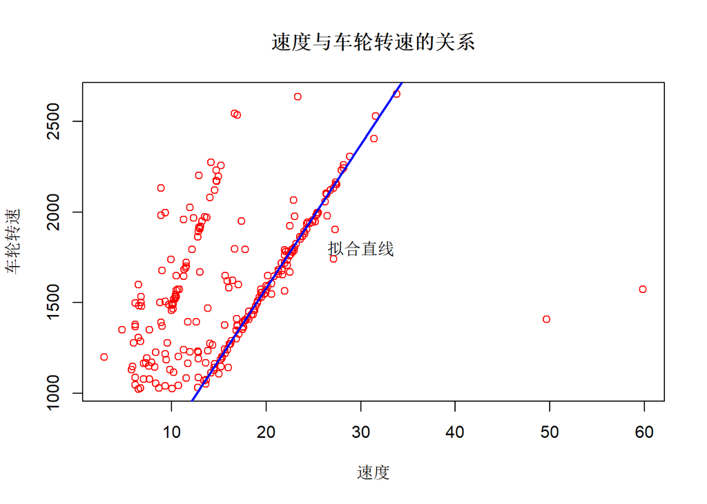

```r
fit6 = rq(data1[data1$class == 0,]$SPEED~data1[data1$class == 0,]$WHEEL, tau = 0.9, data=data1)#以0.92为分位数的对data1的speed和wheel的拟合
plot(data1[data1$class == 0,]$SPEED, data1[data1$class == 0,]$WHEEL,xlab = "速度",ylab = "车轮转速", main = "速度与车轮转速的关系",col= "red")   #画出data1的图
lines(c(0,80),c(0, 79.19540  *(80)),lwd=2, col = "blue") #将拟合直线放在图上
text(30, 1800, "拟合直线")
```

```r
datafit<-fitted(fit6)    #分位数回归拟合的数据
lm<-lm(formula=data1[data1$class == 0,]$WHEEL~datafit)  #提取直线
print(coef(lm))   #拟合直线参数
```

```
## (Intercept)     datafit
##   -28.78448    79.19540
```

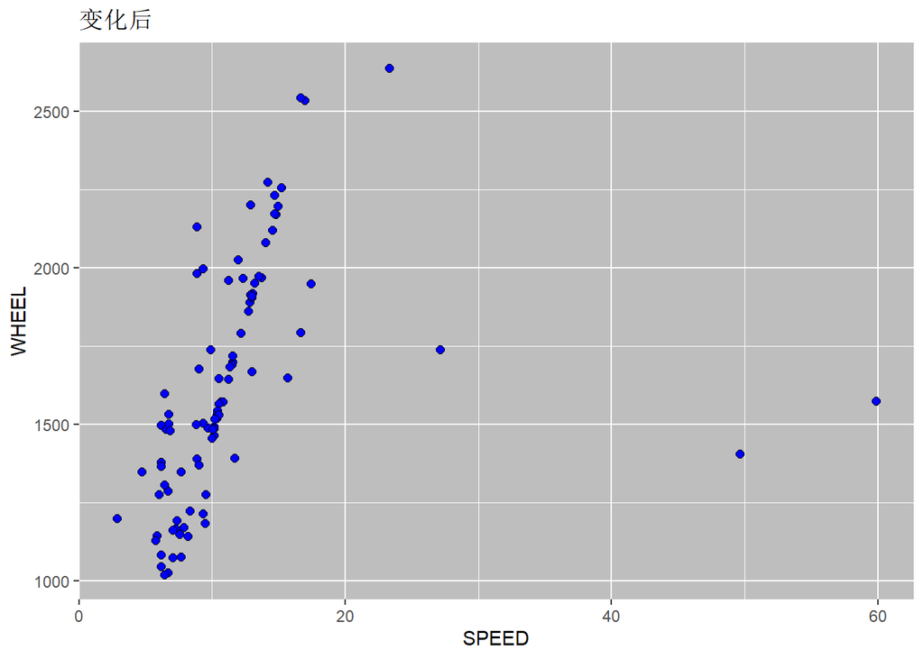

```r
for (i in (1:nrow(data1))) {
  data1$d4[i] = abs( 79.19540  *data1$SPEED[i]-data1$WHEEL[i])/sqrt( 79.19540  * 79.19540  +1)
}   #在data1中扩充一个d列，用来存放到拟合直线的距离
data1$class[data1$d4<5] <- "第五档"
p2<-ggplot(data1[data1$class == 0,], aes(SPEED, WHEEL))+geom_point(size=2,shape=21,fill="blue")+
theme(panel.background = element_rect(fill = "gray"))+labs(title =  bquote("变化后"))
p2
```

```r
data1$class[data1$WHEEL<1000] <- "发动档"
data1$class[data1$class == 0] <- "第六档"
```

剩余的点自动归类为第六档

我们已经将所有档位代表的数据集提取出来了，现在要做的是驾驶员的行为分析，我们画出驾驶员汽车速率的时间序列图

# 任务七:车辆数据时间序列分析

## 根据数据绘制结论图

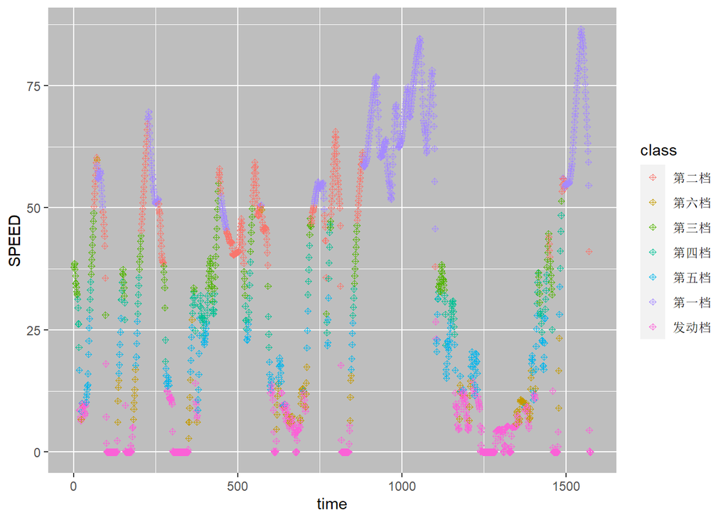

```r
library(ggplot2)
par(mfrow=c(1,2))
q1<-ggplot(data1, aes(time, SPEED, color = class,fill = class))+geom_point(size=1.2,shape=9
                                                                           )+ theme(panel.background = element_rect(fill = "gray"))
q1
```

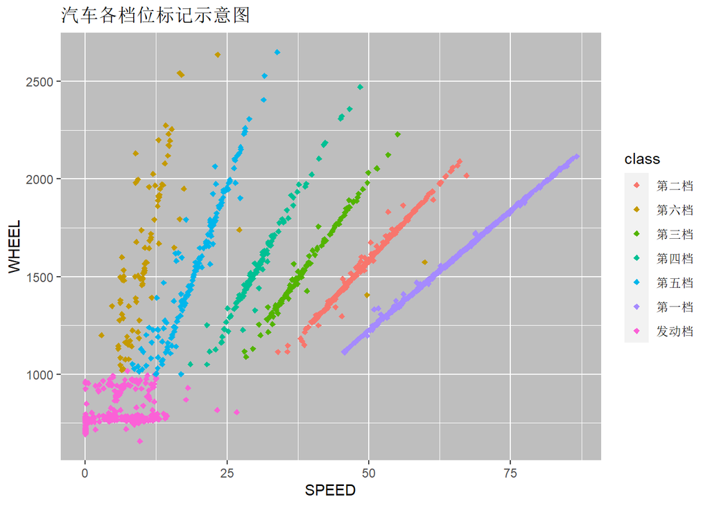

```r
h1<-ggplot(data1, aes(SPEED, WHEEL, color = class,fill = class))+geom_point(size=1.2,shape=23)+ theme(panel.background = element_rect(fill = "gray"))+labs(title =  bquote("汽车各档位标记示意图"))
h1
```

```r
dataclass<-c(nrow(data1[data1$class == "第一档",]),nrow(data1[data1$class == "第二档",]),nrow(data1[data1$class == "第三档",]),nrow(data1[data1$class == "第四档",]),nrow(data1[data1$class == "第五档",]),nrow(data1[data1$class == "第六档",]),nrow(data1[data1$class == "发动档",]))
```

#### 数据提取结果如上，从右图可以看出，提取结果非常顺利，基本将每个类都独立出来了。

## 提取数据子集绘制时间序列图

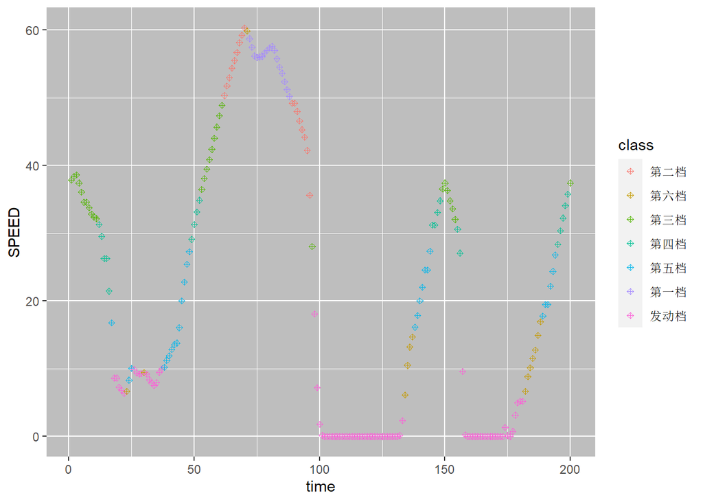

```r
library(ggplot2)
x1<-ggplot(data1[1:200,], aes(time, SPEED, color = class,fill = class))+geom_point(size=1.2,shape=9
                                                                           )+ theme(panel.background = element_rect(fill = "gray"))
x1
```

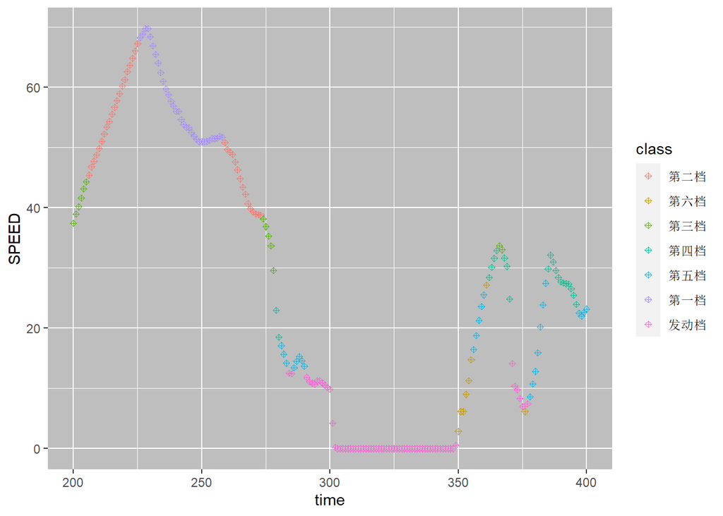

```r
x2<-ggplot(data1[200:400,], aes(time, SPEED, color = class,fill = class))+geom_point(size=1.2,shape=9
                                                                           )+ theme(panel.background = element_rect(fill = "gray"))
x2
```

为了更加清晰地观察，我们可以自由提取数据的子集，上面两张图描绘了前200列数据，与200到400列数据车速与时间序列图，其中点的颜色代表此时小车挡位处于第几档，此时结果瞬间清晰了不少。

## 绘制汽车驾驶员行驶档位饼图

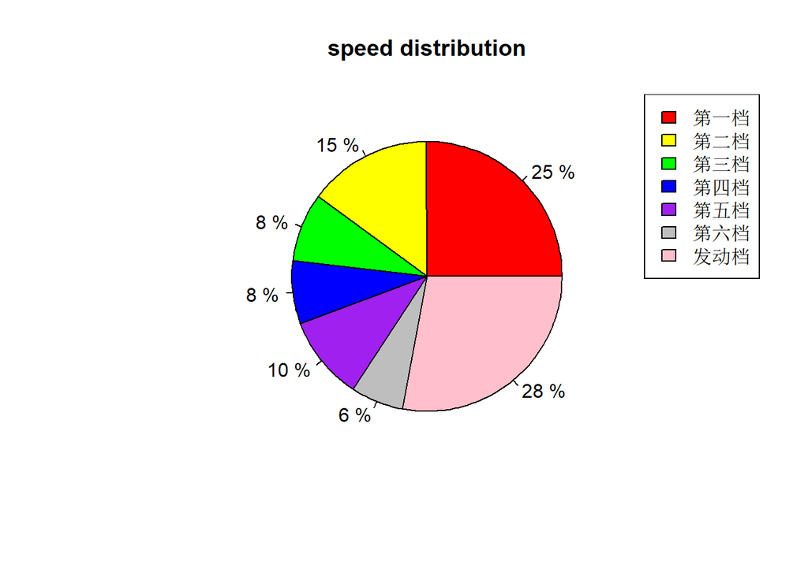

```r
piepercent1 = paste(round(100*dataclass/sum(dataclass)), "%")
names = c("第一档", "第二档", "第三档", "第四档","第五档","第六档","发动档")
colss = c("red","yellow","green","blue","purple","gray","pink")
pie(dataclass, labels=piepercent1, main = "speed distribution", col=colss)
legend("topright", names, cex=1, fill=colss)
```

## 统计变换分析车轮转速与速度的联系

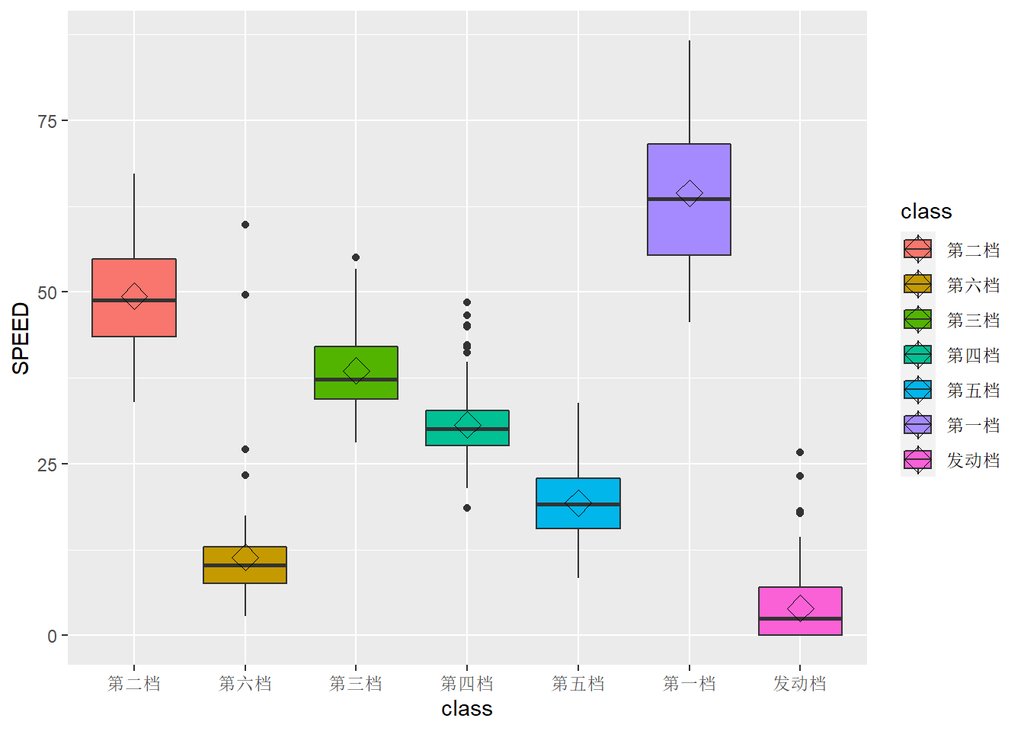

```r
library(ggplot2)
ggplot(data1, aes(x=class,y=SPEED, fill=class)) +
  geom_boxplot() +
  stat_summary(fun=mean, geom="point", shape=5, size=4)
```

从图中可以发现，汽车速度与车轮转速有着明显的断层，说明在不同速度驾驶员会固定调整至不同的档位段，也侧面说明了驾驶员驾驶汽车的行为比较谨慎，应该是一个较为熟练的驾驶员。

# 任务八：总结

本实验，我们对一组车联网数据进行了较为细致的分析，分析方法包括但不限于：初步分析，直方图、散点图，箱线图分析，拟合误差分析，均方误差分析，分位数回归分析，时间序列分析，聚类分析等。

经过此次分析，本实验得出如下分析结论：

1.该实验数据的加速度存在测量误差，现已修复，离群值较少，影响可忽略不计

3.耗油量与加速度有一定的关系，不过不是很大，与其他变量基本无关。

6，汽车高速行驶时，驾驶员基本将档位调整至第一档。

# 收获与致谢

本次实验是在中国科学技术大学温灿红老师的指导下完成的，对此表示诚挚的感谢，这也是本次课程最后的大作业项目，在本课程的学习中，本人学会了很多知识，收获颇丰，也体会了数据思维的培养与数据分析的美妙，学会了两门新的语言，为之后课程的学习打下了基础，在此再次感谢温老师以及交流过的同学！